# Practical quantum computing on IBM quantum devices

Matteo Rossi

7 April 2021

$\newcommand{\ket}[1]{\left|{#1}\right\rangle}$ $\newcommand{\bra}[1]{\left\langle{#1}\right|}$

## Overview

- Introduction to IBM Quantum devices
- How to program them
- Understanding the limitations and improving the results
- Grover's algorithm
- Applications to Open Quantum Systems

## IBM Quantum devices

- Launched in 2016 (a 5-qubit device controlled from the browser)
- Now counts 25 quantum devices from 1 to 65 qubits
- Devices are accessible from the cloud, using the browser or the Qiskit SDK
- Free registration gives immediate access to 8 devices and simulators

https://quantum-computing.ibm.com

## Gate-based quantum computers

[figure not shown]

## Superconducting quantum devices

[figure not shown]

## Noise

Quantum gate-based devices are characterized by various sources of noise

- Finite qubit coherence times $T_1$, $T_2$ (interaction with the environment)
- Gate error rates (imperfect pulses, interaction with env., crosstalk)
- Measurement errors (discrimination errors, imperfect pulses, crosstalk)

[figure not shown]

## Programming IBM Quantum devices

### Qiskit https://qiskit.org

Qiskit is an open-source Python package developed by IBM. It contains tools for:

- the design of quantum circuits
- the simulation of quantum circuits, with and without noise
- the execution on real devices
- the characterization and mitigation of noise
- high-level algorithms that exploit quantum computers

### Installation

```
pip install qiskit
```

### Documentation

[qiskit.org/documentation/](https://qiskit.org/documentation)

### Qiskit textbook

qiskit.org/textbook

### Hello world

We are going to create a two-qubit Bell state:

$$ |\psi\rangle = \frac{|00\rangle + |11\rangle}{\sqrt{2}}$$

First we are going to design the circuit, then we are going to run it on a real device.

```python
from qiskit import (QuantumRegister,   # The qubits
                    ClassicalRegister, # The bits for storing the result
                    QuantumCircuit)    # A quantum circuit

from qiskit import (IBMQ,              # The cloud devices
                    Aer,               # The simulator
                    execute)           # For running circuits
```

```python
# Load IBM Quantum cloud account
IBMQ.load_account()

real_backend = IBMQ.get_provider(hub='ibm-q-research', group='uni-turku-4', project='main'
                                ).get_backend('ibmq_bogota')

statevector_sim = Aer.get_backend('statevector_simulator')
qasm_sim = Aer.get_backend('qasm_simulator')
```

```python
# We create a two-qubit quantum register
qr = QuantumRegister(2)

# And a quantum circuit that uses it
qc = QuantumCircuit(qr)
```

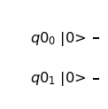

```python
qc.draw(output='mpl', initial_state=True)
```

```python
result = execute(qc, statevector_sim).result()
result.get_statevector()
```

```
array([1.+0.j, 0.+0.j, 0.+0.j, 0.+0.j])
```

The state vector is in the form $$ c_0 |00\rangle + c_1 |01 \rangle + c_2 |10\rangle + c_3 |11\rangle $$

We bring the first qubit into a superposition state $|+\rangle = (|0\rangle + |1\rangle) / \sqrt{2}$.

We use the Hadamard gate

$$ H = \tfrac{1}{\sqrt{2}}\begin{bmatrix} 1 & 1 \\ 1 & -1 \end{bmatrix} $$

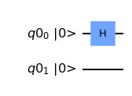

```python
qc.h(0) # Apply the Hadamard gate to qubit 0
qc.draw(output='mpl', initial_state=True)
```

```python
result = execute(qc, statevector_sim).result()
result.get_statevector()
```

```
array([0.70710678+0.j, 0.70710678+0.j, 0.        +0.j, 0.        +0.j])
```

$$ c_0 |00\rangle + c_1 |01 \rangle + c_2 |10\rangle + c_3 |11\rangle $$

> NOTE! In qiskit the first qubit is the rightmost

#### Entanglement

Let's now entangle the qubits using a CNOT (or CX) gate

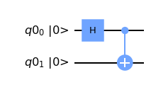

```python
qc.cx(0, 1) # Apply the CNOT gate using qubit 0 as control and qubit 1 as target
qc.draw(output='mpl', initial_state=True)
```

```python
result = execute(qc, statevector_sim).result()
result.get_statevector()
```

```
array([0.70710678+0.j, 0.        +0.j, 0.        +0.j, 0.70710678+0.j])
```

$$ c_0 |00\rangle + c_1 |01 \rangle + c_2 |10\rangle + c_3 |11\rangle $$

#### Measurement

We do not have access to the quantum state on a real device. We need to perform measurements.

On the IBM devices, we can make a projective measurement onto the computational basis $(\ket{0}, \ket{1})$

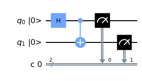

```python
qr = QuantumRegister(2, name='q') # The qubits
cr = ClassicalRegister(2, name='c') # The bits for storing the measurement outcome

qc = QuantumCircuit(qr, cr)

qc.h(0)
qc.cx(0, 1)

qc.measure(0, 0)
qc.measure(1, 1)

qc.draw(output='mpl', initial_state=True)
```

```python
result = execute(qc, qasm_sim).result()
result.get_counts()
```

```
{'00': 546, '11': 478}
```

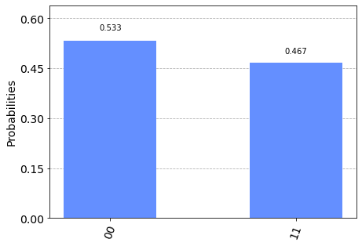

```python
from qiskit.visualization import plot_histogram
plot_histogram(result.get_counts())
```

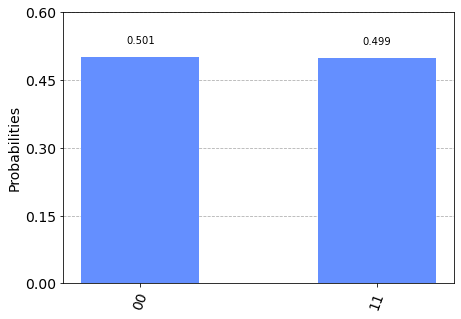

```python
result = execute(qc, qasm_sim, shots=100000).result()
plot_histogram(result.get_counts())
```

### On a real device!

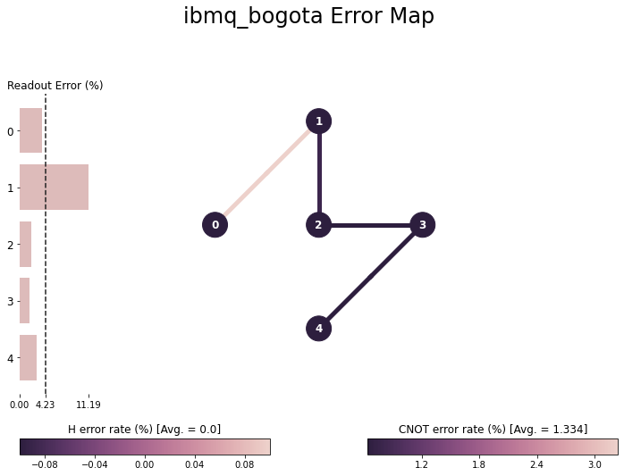

```python
from qiskit.visualization import plot_error_map
plot_error_map(real_backend)
```

```python
from qiskit import transpile
```

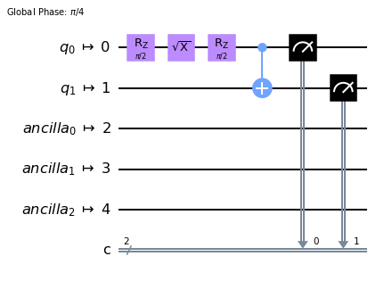

```python
transpiled_qc = transpile(qc, rome_backend)
transpiled_qc.draw(output='mpl')
```

```python
job = execute(qc, real_backend, shots=8192) # Maximum number of shots
```

Jobs are queued and executed after a while. One can monitor the job progress from [here](https://quantum-computing.ibm.com/jobs), or from qiskit

```python
print(job.job_id())
```

```
606b1fb34a9caf2ba0a5e8a2
```

```python
job.status()
```

```
<JobStatus.VALIDATING: 'job is being validated'>
```

#### Results

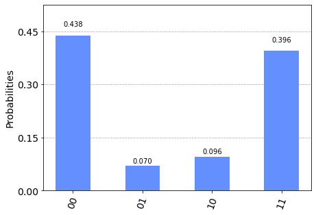

```python
result = real_backend.retrieve_job('606b0b7e24c5ff27bbbc36f1').result()
plot_histogram(result.get_counts())
```

We obtain spurious counts, due to the noise on the device (mostly, *CNOT errors* and *measurement errors*)

#### Exercise

The fact that we measure `'00'` and `'11'` with high probability does not mean that we have prepared an entangled state. The two qubit may simply be classically correlated.

In order to test whether entanglement is present, one should check if the Bell inequalities are violated.

This can be done as an exercise!

## Improving the performance of your circuits

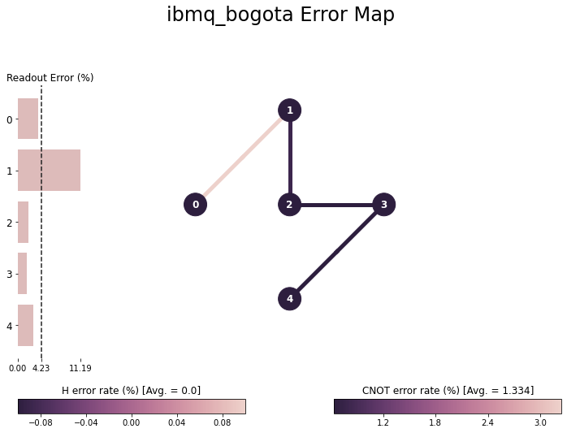

```python
plot_error_map(real_backend)
```

We run the circuit on the worst qubits, 0 and 1!

Let's run it on qubits 2 and 3.

```python
job = execute(qc, real_backend, initial_layout=[2, 3], shots=8192)
```

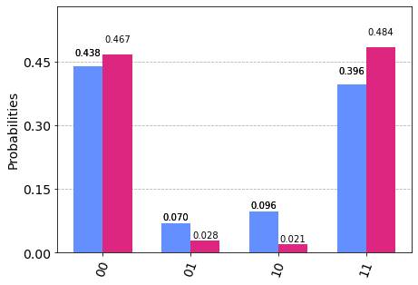

```python
result_2 = real_backend.retrieve_job('606b0defffee0071e3ad1759').result()
plot_histogram([result.get_counts(), result_2.get_counts()])
```

### GHZ state

We now prepare the state $$\frac{\ket{000} + \ket{111}}{\sqrt{2}}$$

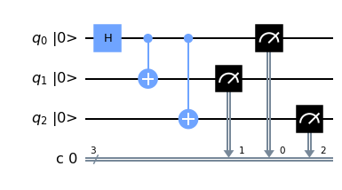

```python
qc = QuantumCircuit(3, 3)

qc.h(0)
qc.cx(0, 1)
qc.cx(0, 2)

qc.measure(0, 0)
qc.measure(1, 1)
qc.measure(2, 2)

qc.draw(output='mpl', initial_state=True)
```

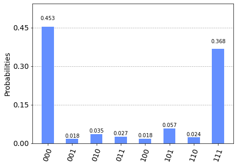

```python
ghz_job = rome_backend.retrieve_job('604b9b176327bc240892ea9f')

plot_histogram(ghz_job.result().get_counts())
```

We see a lot of spurious counts and an asymmetry between $000$ and $111$.

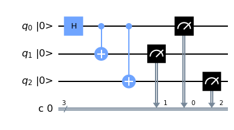

```python
qc.draw(output='mpl', initial_state=True)
```

The circuit above can not be run on `ibmq_rome`. [Link](https://quantum-computing.ibm.com/services?system=ibmq_rome&systems=yours). This is what is actually run:

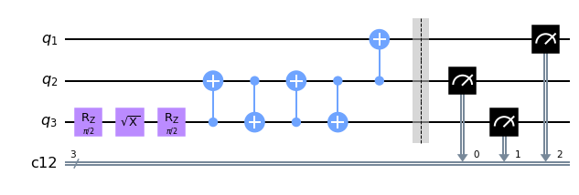

```python
from qiskit.assembler import disassemble
real_circuit = disassemble(ghz_job.qobj())[0][0]
real_circuit.draw(output='mpl', idle_wires=False)
```

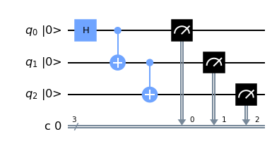

```python
qc = QuantumCircuit(3, 3)

qc.h(0)
qc.cx(0, 1)
qc.cx(1, 2)

qc.measure(0, 0)
qc.measure(1, 1)
qc.measure(2, 2)

qc.draw(output='mpl', initial_state=True)
```

```python
ghz_job_2 = rome_backend.retrieve_job('604b9c5912bd786429f66b70')
```

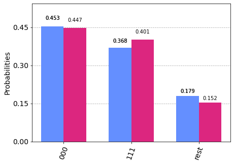

```python
plot_histogram([ghz_job.result().get_counts(),
                ghz_job_2.result().get_counts()],number_to_keep=2)
```

#### Measurement error mitigation

The projective measurement of the qubit is a complicated process which involves the attribution of a label (0 or 1) to a measured microwave signal.

There is a certain probability that each qubit is read in the wrong state.

This probability can be easily accounted for. Given $N$ qubits of interest, we can prepare each of the $2^N$ possible basis states, immediately measure them, and see what probability exists for each outcome.

> NOTE This is not quantum error correction

```python
# Import measurement calibration functions
from qiskit.ignis.mitigation.measurement import (complete_meas_cal,
                                                 CompleteMeasFitter)
```

```python
meas_calibs, state_labels = complete_meas_cal(qr=qr, qubit_list=[0, 1, 2], circlabel='mcal')
```

`meas_calibs` is a list of circuits where the $N$ qubits are prepared in all $2^N$ vectors of the computational basis and measured.

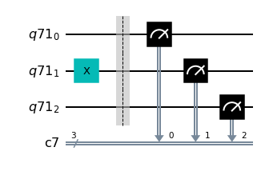

```python
meas_calibs[2].draw(output='mpl')
```

This one prepares $\ket{010}$, for example.

We run the calibration circuits on the device

```python
calib_job = qiskit.execute(meas_calibs, backend=rome_backend, shots=8192)
```

```python
calib_job = rome_backend.retrieve_job('604bb28f09a82b3a2d6f1164')
cal_results = calib_job.result()
```

The results can now be processed with `CompleteMeasFitter`, which constructs a calibration matrix

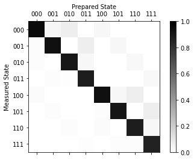

```python
meas_fitter = CompleteMeasFitter(cal_results, state_labels, qubit_list=range(3), circlabel='mcal')
# Plot the calibration matrix
meas_fitter.plot_calibration()
```

The calibration matrix can now be used to mitigate readout errors from other circuits.

```python
meas_filter = meas_fitter.filter
mitigated_counts = meas_filter.apply(ghz_job_2.result()).get_counts()
```

```python
mitigated_counts
```

```
{'000': 3817.006359236269,
 '001': 33.991776567931545,
 '010': 27.813033367504325,
 '011': 194.0287482424135,
 '100': 130.1552241803393,
 '101': 63.80495485989637,
 '110': 138.16215962025257,
 '111': 3787.037743925394}
```

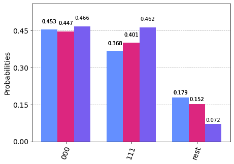

```python
plot_histogram([ghz_job.result().get_counts(),
                ghz_job_2.result().get_counts(),
               mitigated_counts],number_to_keep=2)
```

Measurement noise mitigation improved the results quite significantly.

> NOTE: In longer circuits, gate errors and qubit relaxation become the most important source of noise and measurement mitigation will be less impactful.

## Tomography

We don't have access to the quantum state $\ket{\psi}$.

But we can reconstruct it by performing a suitable set of measurements on multiple copies of the state.

> Since noise is present, or we are interested in part of the qubits of the system, we will in general talk about an **ensemble state**, described by the **density operator $\rho$**.

### Tomography of a qubit

The density operator of a qubit can be written as

$$ \rho = \frac 12 (\mathbb{I} + a_x \sigma_x + a_y \sigma_y + a_z \sigma_z) $$

and $a_x = \text{Tr}[\rho \sigma_x] = \langle \sigma_x \rangle$ etc.

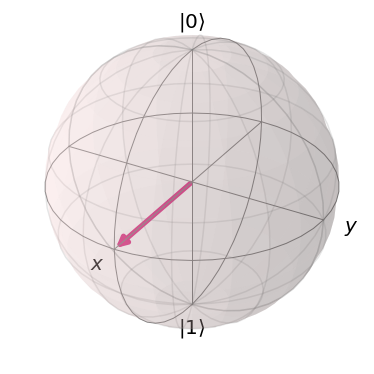

```python
plot_bloch_vector([1, 0, 0])
```

By measuring $\langle \sigma_x \rangle$, $\langle \sigma_y \rangle$, $\langle \sigma_z \rangle$, we can reconstruct $\rho$.

IBM devices measure projections along $\sigma_z$. How do we measure the other expectation values?

[figure not shown]

Notice that simply writing $\rho = \frac 12 \left(\mathbb{I} + \langle \sigma_x \rangle \sigma_x + \langle \sigma_y \rangle \sigma_y + \langle \sigma_z \rangle \sigma_z\right)$ may give non-physical density operators.

Other techniques are used, for example maximum-likelihood reconstruction.

For two qubits, we need to measure all possible combinations $\langle \sigma_x \otimes \sigma_x \rangle, \langle \sigma_x \otimes \sigma_y \rangle, \ldots, \langle \sigma_z \otimes \sigma_z \rangle$ and so on.

#### Example: tomography of the Bell state

The Bell state is $\ket{\psi} = (\ket{00} + \ket{11})/\sqrt{2}$. The corresponding density matrix is

$$\rho = \ket{\psi}\bra{\psi} = \begin{pmatrix} \frac 12 & 0 & 0 & \frac 12 \\ 0 & 0 & 0 & 0 \\ 0 & 0 & 0 & 0 \\ \frac 12 & 0 & 0 & \frac 12 \end{pmatrix}$$

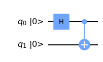

```python
qc = QuantumCircuit(2)
qc.h(0)
qc.cx(0, 1)
qc.draw(output='mpl', initial_state=True)
```

```python
# Tomography
from qiskit.ignis.verification.tomography import state_tomography_circuits
from qiskit.ignis.verification.tomography import StateTomographyFitter
```

```python
tomo_circuits = state_tomography_circuits(qc, [0, 1])
print("Tomography circuits:",len(tomo_circuits))
print(*(c.name for c in tomo_circuits))
```

```
Tomography circuits: 9
('X', 'X') ('X', 'Y') ('X', 'Z') ('Y', 'X') ('Y', 'Y') ('Y', 'Z') ('Z', 'X') ('Z', 'Y') ('Z', 'Z')
```

```python
real_job = execute(tomo_circuits, backend=santiago_backend, shots=8192)
exp_tomo_fitter = StateTomographyFitter(real_job.result(), tomo_circuits)
exp_rho = exp_tomo_fitter.fit()
```

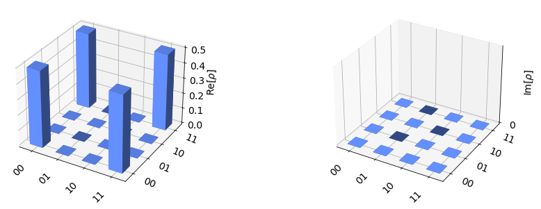

```python
from qiskit.visualization import plot_state_city
# Exact state
psi = execute(qc, statevector_sim).result().get_statevector()
plot_state_city(psi)
```

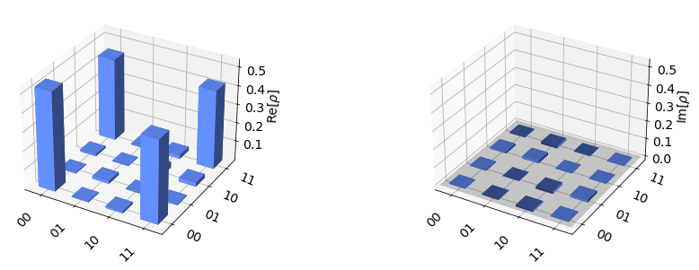

```python
# Experimental state
plot_state_city(exp_rho)
```

```python
from qiskit.quantum_info import state_fidelity
state_fidelity(psi, exp_rho)
```

```
0.9194157587711151
```

## Grover search

Finds a marked item in a list of $N$ items in $O(\sqrt{N})$ iterations.

Offers a quadratic speed-up compared to classical search.

### Example

Let's run the grover search on a list of 8 elements. The elements can be encoded in 3 qubits.

Let's assume that the correct answer is `101`.

So we have a oracle function $f(101) = 1$ and $f(x) = 0$ elsewhere.

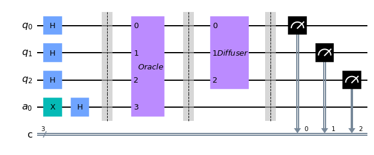

```python
qc.draw(output='mpl')
```

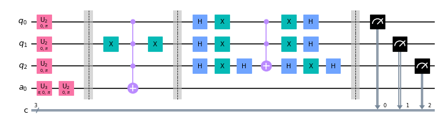

```python
qc.decompose().draw(output='mpl', scale=.8)
```

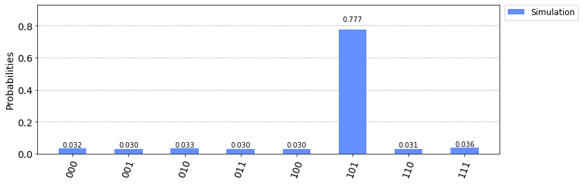

```python
grover_sim = execute(qc, qasm_sim, shots=8192)
plot_histogram(grover_sim.result().get_counts(),legend=['Simulation'], figsize=[12, 4])
```

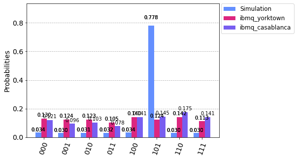

```python
plot_histogram([grover_sim.result().get_counts(),
               grover_ibmqx.result().get_counts(),
               grover_cb.result().get_counts()], legend=['Simulation', 'ibmq_yorktown', 'ibmq_casablanca'])
```

The real experiments are garbage. No need to do the measurement error mitigation...

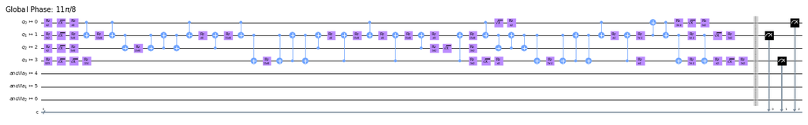

```python
tqc_cb.draw(output='mpl', scale=.4, fold=100)
```

The circuit is too long and with too many CNOT gates.

### Open quantum systems with IBM Quantum

We can use IBM devices as quantum simulators.

[figure not shown]

We used the IBM devices to simulate open quantum dynamics:

- Amplitude damping channel
- Depolarizing channel
- Pauli channel
- Reservoir engineering
- Collisional models

## Depolarizing channel

With probability $1-p$ the qubit remains intact, with probability $p$ becomes maximally mixed

[figure not shown]

The circuit to implement the channel

The rotation angle for the $R_y$ gates depends on the value of $p$.

A tomographic reconstruction of $\rho_S$ for various values of $p$

[figure not shown]

### Textbook on open quantum systems with qiskit

Written by Daria Anttila, Guillermo García-Pérez, Matteo Rossi, Boris Sokolov

https://matteoacrossi.github.io/oqs-jupyterbook

[figure not shown]

## Take-home messages

- Current quantum computers are limited by noise and connectivity layout
- We can't use them as universal quantum computers
- We need to design the circuits by hand to minimize the number of gates
- We can still use them as quantum simulators for research and for near-term applications (see Guille's lecture)